# Convergence in Probability vs. Almost Sure Convergence - A Visual Explanation

These statements look somewhat similar at first glance, but they are describing very different notions of what it means for a sequence of random variables to converge. Here we look at a particular sequence of random variables $X_n$ that converges in probability but not almost surely, and use a visualization to build some intuition for what each of these definitions really means.

# An Example Sequence $X_n$

Let $U \sim Uniform(0, 1)$, and define the sequence of random variables $X_n$ like so:

$X_1 = U + I_{[0, 1]}(U)$

$X_2 = U + I_{[0, \frac{1}{2})}(U)$

$X_3 = U + I_{[\frac{1}{2}, 1]}(U)$

$X_4 = U + I_{[0, \frac{1}{3})}(U)$

$X_5 = U + I_{[\frac{1}{3}, \frac{2}{3})}(U)$

$X_6 = U + I_{(\frac{2}{3}, 1]}(U)$

$X_7 = U + I_{[0, \frac{1}{4})}(U)$

...

For $n \in \mathbb{N}$, where $I_A(U)$ is the indicator function that takes value $1$ when $U \in A$ and $0$ otherwise. What is this sequence doing? If we fix $u = \frac{\pi}{4} \approx 0.7854$. We see that clearly $u \in [0, 1]$ and so:

$$ X_1(u) = u + I_{[0, 1]}(u) = u + 1 = \frac{\pi}{4} + 1 $$

Since $u \notin [0, \frac{1}{2})$ we will have that:

$$ X_2(u) = u = \frac{\pi}{4} $$

Notice the following two properties of the sequence $X_n(u)$ that we've constructed:

- 1) **The sequence finds $u$ less and less frequently as n increases**

- 2) **The sequences always eventually finds $u$ again - it therefore finds $u$ "infinitely often"**

Even though the sequence finds $u$ less and less frequently, each scan that it makes covers the entire unit interval. Therefore it will always find $u$ again, even though it will take longer and longer to do so. We can say that $X_n$ finds $u$ "infinitely often" in the sense that there does not exist a large enough $n^*$ such that $X_n$ doesn't find $u$ for all $n > n^*$.

# Visualizing the Relationship Between $X_n$ and $U$

When $u$ is fixed (as above), the sequence $X_n(u)$ is not a sequence of random variables - it is a regular sequence corresponding to one realization of $X_n$. Let's now build a visualization for the sequence $X_n$. One way we can visualize what $X_n$ is doing for all values of $U$ is to build a table (of sorts) with elements of $X_n$ as the rows and possible values of $U$ as the "columns." Since $U$ takes an uncountable number of values, the "column" values for each row will just be the unit interval. On each of these intervals we highlight in red the region for which $X_n$ "finds" $U$, which is the region where $X_n \neq U$. This visualization nicely illustrates $X_n$'s behavior of continuously "scanning" across the unit interval with a progressively smaller window.

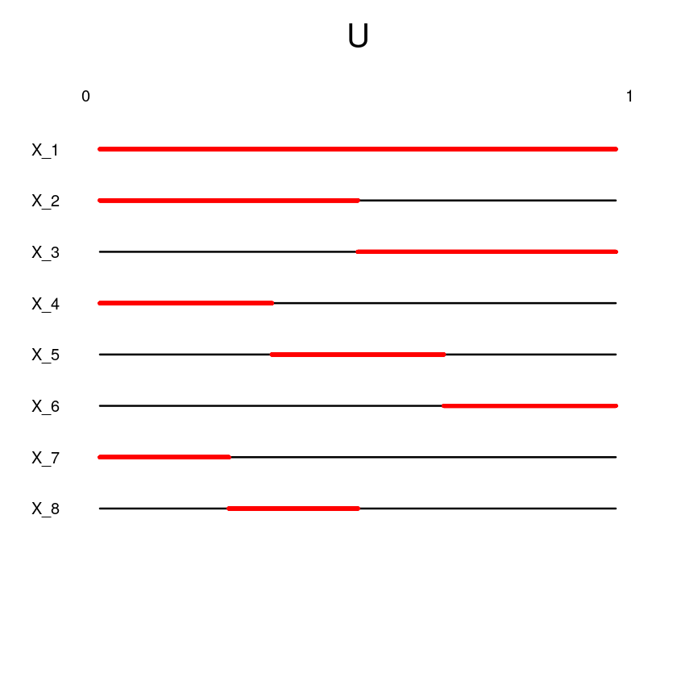

# $X_n$ Converges to $U$ in Probability

Since $U$ is uniformly distributed over the interval, for each $X_n$ we have that $P(X_n \neq U)$ is just the length of the red bar in $X_n$'s corresponding row. Clearly $P(X_n \neq U)$ is decreasing in $n$ - consider the row in our table corresponding to $X_{1276}$:

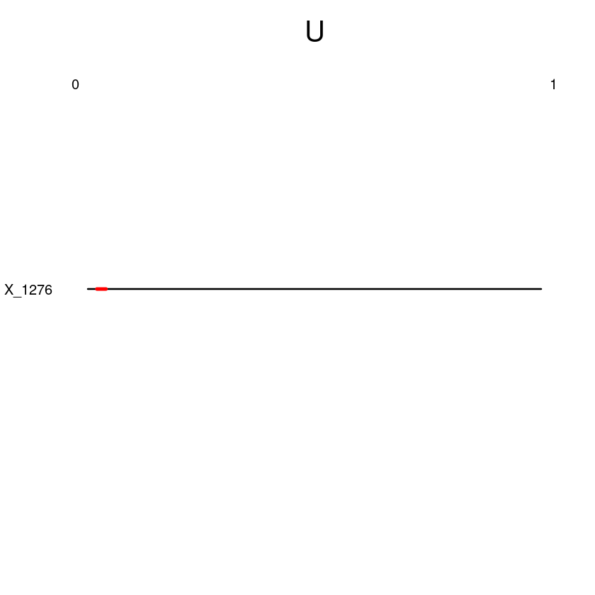

# $X_n$ Does Not Converge to $U$ Almost Surely

Now let's use our visualization differently, and look at columns instead of rows. Suppose we choose $u = \frac{\pi}{4}$ and draw an infinite vertical line through all of the $X_n$ row intervals in our table at $U=u$. We see that we will intersect an infinite number of red bars, or in other words there are an infinite number of elements of $X_n$ for which $X_n(u) \neq U$. This is exactly property (2) from above!

Moreover, we can see from our table that for *any* value of $u \in (0, 1)$ that we choose, a vertical line drawn through our table at $U=u$ will intersect an infinite number of red bars. Therefore, it must be that for every $u$ there are an infinite number of terms of $X_n$ for which $X_n(u) \neq U \implies X_n(u) - U = 1$. Thus, the probability of this set of "badly behaved" $u$ values is in fact equal to 1. By definition this means that $X_n$ does **not** converge almost surely to $U$. To formalize this, we can describe this badly behaved set as follows: this set contains every $u$ such that for any value of $k \in \mathbb{N}$, $X_n(u) \neq u$ for some $n > k$. In other words, this is the set of $u$ values for which $X_n(u) \neq u$ *infinitely often*, which is often expressed in set notation like so:

$$ \cap_{k=1}^\infty \cup_{n \geq k} \{u | X_n(u) \neq U \} $$

Our visualization shows us that this set is in fact equal to the entire interval $(0, 1)$, and therefore:

$$ P(U \in \cap_{k=1}^\infty \cup_{n \geq k} \{u | X_n(u) \neq U \}) = P(U \in (0, 1)) = 1 \neq 0 $$

# Conclusion

This example hopefully provides some intuition for why convergence in probability and almost sure convergence are very different notions of what it means for a sequence of random variables to converge. Convergence in probability is concerned with what happens at *specific* elements in the tail of the sequence, which we considered in our visualization by examining rows in our table corresponding to tail elements $X_n$. Almost sure convergence, on the other hand, is concerned with what happens *across* elements in the tail of our sequence. We explored this by considering the columns in our table for which our sequence was sufficiently far from our limiting random variable an infinite number of times.

Keep in mind that we constructed our visualization specifically to illustrate this example - it obviously does not generalize to all sequences of random variables. Indeed it does not even generalize to a modified version of $X_n$ where the size of the "jumps" vanishes in n! Nevertheless I hope that it is still a useful tool for illustrating this specific case.

# References

https://andrewcharlesjones.github.io/journal/convergence.html

https://en.wikipedia.org/wiki/Convergence_of_random_variables#Definition_2